# Markdown Report

Casper M. Lyngbye, Thea A. Dencker, Jonas N. Rasmussen, Lucy. D. Borhi

2025-05-05

## Loading libraries

```r
library(ampvis2)
library(leaflet)
library(readxl)
library(tidyverse)
library(ggthemes)
library(patchwork)
library(kableExtra)
library(exifr)
```

## Setting theme

```r
theme_set(theme_classic())
```

## Creating maps

For each sample taken, pictures were taken of the sampling location. This was done in order to be able to extract metadata, which could be used for creating the maps. This didn’t work out as planned, as some of the GPS-coordinates proved to be inaccurate;

```r
pictures = list.files(path = "Pictures/", pattern = "*.HEIC", full.names = TRUE)

dat <- read_exif(pictures)

dat.gps = select(dat,
                 SourceFile, DateTimeOriginal,
                 GPSLongitude, GPSLatitude,
                 GPSTimeStamp)
leaflet(dat.gps) %>%
  addProviderTiles("Esri.WorldImagery") %>%
  addMarkers(~ GPSLongitude, ~ GPSLatitude)
```

[interactive chart not shown]

As shown above, while some GPS-coordinates are correct, others are not. Therefore, the GAIA GPS app was also used in order to obtain coordinates for the making of maps. The coordinates provided by GAIA proved to be more consistent, as shown below. However, only the sample locations were noted, as the 3 subsamples were excluded:

```r
datgps = read_excel("Data/Sample_location.xlsx")

leaflet(datgps,
        options = leafletOptions(zoomControl = FALSE)) %>%
  addProviderTiles("Esri.WorldImagery") %>%
  addCircleMarkers(lng = ~ `long _x`,
                   lat = ~ lat_y,
                   radius = 3,
                   color = "dodgerblue",
                   label = ~Location,
                   labelOptions = labelOptions(noHide = TRUE,
                                               textOnly = TRUE,
                                               direction = "top",
                                style = list(
                                  "color" = "white",
                                  "font-family" = "serif",
                                  "font-style" = "bold",
                                  "box-shadow" = "3px 3px rgba(0,0,0,0)",
                                  "font-size" = "14px",
                                  "border-color" = "rgba(0,0,0,0)"
                                )))%>%
  addMiniMap(position = "topright",
             height = 250,
             width = 200,
             zoomLevelOffset = -6.69,
             aimingRectOptions = list(color = "red", weight = 1, clickable = FALSE))%>%
  addScaleBar(position = "topleft")
```

[interactive chart not shown]

## Data from laboratory

The number of dead and pupated waxworms during the experiments was noted. There were three different rebaiting days, and therefore three sheets - one for each baiting period. These are bound together and mutated, in order to transform the sample and subsample into a factor, rather than an integer.

```r
df =  rbind(read_excel("Data/Data.xlsx", sheet = 1),
            read_excel("Data/Data.xlsx", sheet = 2),
            read_excel("Data/Data.xlsx", sheet = 3)) %>%
      mutate(sample    = as.factor(sample),
             subsample = as.factor(subsample))
head(df, 10)
```

```
## # A tibble: 10 × 7
##    location date          sample subsample dead.worms pupaeted infected
##    <chr>    <chr>         <fct>  <fct>          <dbl>    <dbl> <chr>
##  1 Forest   First baiting 1      1                  0        0 Negative
##  2 Forest   First baiting 1      2                  1        0 Positive
##  3 Forest   First baiting 1      3                  0        0 Negative
##  4 Forest   First baiting 2      1                  1        0 Negative
##  5 Forest   First baiting 2      2                  0        0 Negative
##  6 Forest   First baiting 2      3                  0        0 Negative
##  7 Forest   First baiting 3      1                  0        0 Negative
##  8 Forest   First baiting 3      2                  0        0 Negative
##  9 Forest   First baiting 3      3                  0        0 Negative
## 10 Forest   First baiting 4      1                  0        0 Negative
```

## Plots

We use the `tidyverse` package, which includes `ggplot2` for all plots.

### Positive Negative Plot of samples

After confirming that EPNs were present, while examining the samples under the microscope, their occurence was noted in a separate column. This was done in order to survey which of the samples were positive for EPNs. This could be used and visualized as shown below:

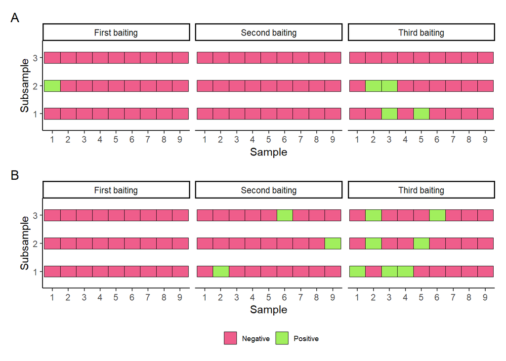

```r
grid_forest = df %>%
  filter(location == "Forest")%>%
  ggplot(aes(sample,subsample))+
  geom_tile(aes(fill = infected, width = 1, height = 0.4), alpha  = .8, color = "black")+
  scale_fill_manual(values = c("#eb346e", "#89eb34"),
                    name = "")+
  labs(x = "Sample",
       y = "Subsample")+
  facet_wrap(~date)

grid_beet = df %>%
  filter(location == "Beet Field")%>%
  ggplot(aes(sample,subsample))+
  geom_tile(aes(fill = infected, width = 1, height = 0.4), alpha  = .8, color = "black")+
  scale_fill_manual(values = c("#eb346e", "#89eb34"),
                    name = "")+
  labs(y = "Subsample",
       x = "Sample")+
  facet_wrap(~date)

PosNegPlot = (grid_forest/grid_beet) +
              plot_annotation(tag_levels = "A")+
              plot_layout(guides = "collect") & theme(legend.position = 'bottom',
                                          legend.text=element_text(size=7),
                                          legend.key.size = unit(.45, "cm"))
PosNegPlot
```

Saving the plot;

```r
ggsave(plot = PosNegPlot,
       filename = "PosNegPlot.png",
       path = "Plots/",
       width =5,
       height = 5,
       units = "in")
```

### Mean pupaeted and died

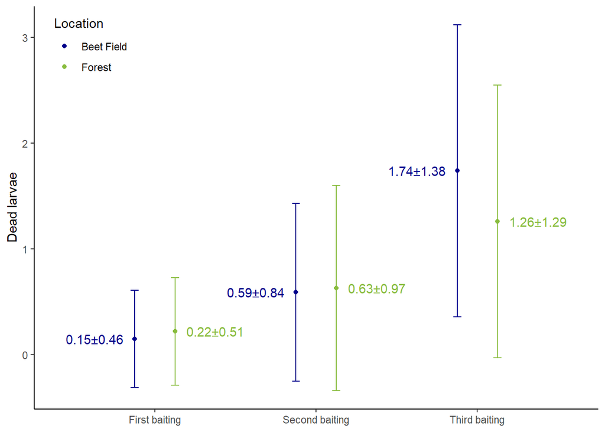

```r
mean_dead_plot = df %>%
  #filter(infected == "Positive")%>%
  group_by(location, date)%>%
  summarise(meanDead = round(mean(dead.worms),2),
            sdDead  =  round(sd(dead.worms),2),
            .groups = "drop") %>%
  ggplot(aes(date, meanDead, color = location,
             label = paste(meanDead, sdDead, sep = "±")),
             parse = TRUE)+
  geom_errorbar(aes(ymin = meanDead-sdDead,
                    ymax = meanDead+sdDead),
                width = .1,
                position = position_dodge(0.5),
                show.legend = F)+
  geom_point(position = position_dodge(0.5))+
  geom_text(position = position_dodge(1.5),
            show.legend = F)+
  labs(
    y= "Dead larvae",
    x= NULL)+
    scale_color_manual(name = "Location",
                       values = c("Beet Field" = "darkblue",
                                  "Forest" = "#88bc3d"))+
  theme(legend.position = c(0.1, 0.9))
mean_dead_plot
```

We save this plot

```r
ggsave(plot = mean_dead_plot,
       filename = "dead_larvae.png",
       path = "Plots/",
       width =6,
       height = 4,
       units = "in")
```

Of all positive samples, how many were found dead in the samples?

```r
df %>%
  filter(infected == "Positive")%>%
  group_by(location, date)%>%
  summarise(n = n(),
            meanDead = mean(dead.worms),
            sdDead = sd(dead.worms),
            .groups = "drop")
```

```
## # A tibble: 4 × 5
##   location   date               n meanDead sdDead
##   <chr>      <chr>          <int>    <dbl>  <dbl>
## 1 Beet Field Second baiting     3     1.33  0.577
## 2 Beet Field Third baiting      7     3.14  1.07
## 3 Forest     First baiting      1     1    NA
## 4 Forest     Third baiting      4     3     0.816
```

### Positive and negative mean dead larvae

We can also plot the amount of dead larvae, vs the amount of positive dead larvae;

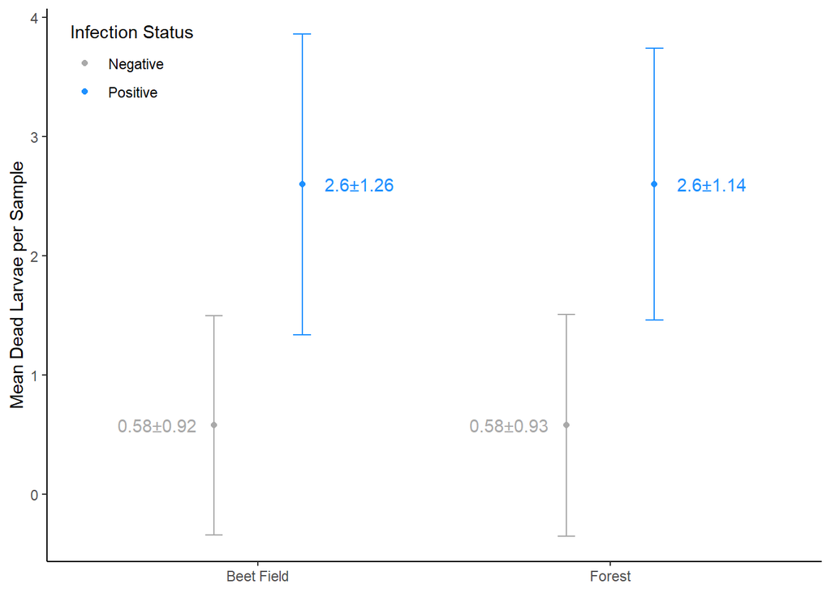

```r
pos_neg_dead = df %>%
  group_by(infected, location)%>%
  summarise(mean_dead = round(mean(dead.worms),2),
            sd_dead = round(sd(dead.worms),2))%>%
  ggplot(aes(location, mean_dead, color = infected,
             label = paste(mean_dead, sd_dead, sep = "±")),
                      parse = TRUE)+
  geom_errorbar(aes(ymin = mean_dead-sd_dead,
                    ymax = mean_dead+sd_dead),
                width = .1,
                position = position_dodge(0.5),
                show.legend = F)+
  geom_point(position = position_dodge(0.5))+
  geom_text(position = position_dodge(1.15),
            show.legend = F)+
  labs(x = NULL,
       y = "Mean Dead Larvae per Sample",
       color = "Infection Status")+
  scale_color_manual(values = c("Negative" = "darkgray",
                                "Positive" = "dodgerblue"))+
  theme(legend.position = c(0.11, 0.9))
pos_neg_dead
```

We save this plot

```r
ggsave(plot = pos_neg_dead,
       filename = "pos_neg_dead.png",
       path = "Plots/",
       width =6,
       height = 4,
       units = "in")
```